# Lending Club Loan Riskiness Analysis

### Final Notebook

Aguillar, Fallon, Goswami

Basic structure of the notebook:

*Please Note: a lot of the cleaning cells can only be run once, running them twice without commenting things out may require the notebook to be re-started*

**Section II: Initial Analysis and Visualization**  
Before running our models, we do some initial analysis on the dataset to better understand what we were dealing with. This is the section where, for example, we learned that the dataset is quite imbalanced. In this section, we also end up dropping all loans granted in 2016, because we realized that these loans have not had enough time to mature and demonstrate their 'riskiness'.

**Section III: Model Selection and Optimization**  
After cleaning, we then fit three models: Random forests, Logistic Regression (with L1 and L2 penalties), and Support Vector Classifier. We optimize for the parameters of each of these models.

**Section IV: Final Results**  
Once we have optimized our models, we use the optimal parameters to fit the entire dataset. Since we are more interested in within class accuracy than overall accuracy, we present our final results in terms of a ROC and Precision/Recall curve, to visualize the relative performance of each of the optimized models on these metrics.

### Importing Datasets and Packages

```python
import datetime as dt

import pandas as pd
pd.set_option('display.max_columns', 100)

import numpy as np
import matplotlib.pyplot as plt
%matplotlib inline

from sklearn import preprocessing
from sklearn.preprocessing import Imputer
from sklearn import tree
from sklearn import ensemble
from sklearn import svm
from sklearn.cross_validation import KFold
from sklearn.linear_model import LogisticRegression as LogReg
from sklearn.linear_model import LogisticRegressionCV as LogRegCV
from sklearn.tree import DecisionTreeRegressor, DecisionTreeClassifier, export_graphviz
from sklearn.grid_search import GridSearchCV
from sklearn.cross_validation import train_test_split
from sklearn import metrics
from sklearn.metrics import precision_recall_curve
import StringIO
import matplotlib
import matplotlib.pyplot as plt
# special matplotlib argument for improved plots
from matplotlib import rcParams
import matplotlib.patches as mpatches
from IPython.display import Image
import pydotplus
%matplotlib inline
from sklearn.feature_extraction import DictVectorizer

import glob

from IPython.core.interactiveshell import InteractiveShell
InteractiveShell.ast_node_interactivity = "all"

low_memory = False
```

```python
files = glob.glob('/Users/Dwijo/Google Drive/CS 109/Homework/Final Project/Milestone 3/LC Data/LoanStats3[a-d].csv.zip')
files2 = glob.glob('/Users/Dwijo/Google Drive/CS 109/Homework/Final Project/Milestone 3/LC Data/LoanStats_2016Q[1-2].csv.zip')
files = files + files2

print 'IMPORT LOAN DATA\n'
print 'files being imported:\n' + str(files) +'\n'

#keep track of concatenation
i = 0

#start with the first file
data = pd.read_csv(files[0], header = 1, compression = 'zip')
### NOTE ADDITION OF CATEGORICAL YEAR COLUMN###

print 'file ' + str(i) + ' complete'

year_list = ['2012-2013', '2014', '2015', '2016']

#loop through remaining files
for file in files[1:len(files)]:
    data_cat = pd.read_csv(file, header = 1, compression = 'zip')
    ## There is actually an issue date variable, commenting this out
    #data_cat.loc[:, 'year'] = year_list[i]
    data = pd.concat((data, data_cat), axis = 0)

    #keep track of loading process
    i+=1
    print 'file ' + str(i) + ' complete'

    if i == len(files):
        print 'import complete'

#sense check shape, size etc. of dataset
size = np.shape(data)
variables = pd.DataFrame(data.columns.values, columns = ['Variables'])
data.head(n=5)
```

```
IMPORT LOAN DATA

files being imported:
['/Users/Dwijo/Google Drive/CS 109/Homework/Final Project/Milestone 3/LC Data/LoanStats3a.csv.zip', '/Users/Dwijo/Google Drive/CS 109/Homework/Final Project/Milestone 3/LC Data/LoanStats3b.csv.zip', '/Users/Dwijo/Google Drive/CS 109/Homework/Final Project/Milestone 3/LC Data/LoanStats3c.csv.zip', '/…
```

```
file 0 complete
```

```
file 1 complete
```

```
file 2 complete
```

```
file 3 complete
file 4 complete
file 5 complete
```

|  | id | member_id | loan_amnt | funded_amnt | funded_amnt_inv | term | int_rate | installment | grade | sub_grade | emp_title | emp_length | home_ownership | annual_inc | verification_status | issue_d | loan_status | pymnt_plan | url | desc | purpose | title | zip_code | addr_state | dti | delinq_2yrs | earliest_cr_line | inq_last_6mths | mths_since_last_delinq | … |
| --- | --- | --- | --- | --- | --- | --- | --- | --- | --- | --- | --- | --- | --- | --- | --- | --- | --- | --- | --- | --- | --- | --- | --- | --- | --- | --- | --- | --- | --- | --- |
| 0 | 1077501 | 1296599.0 | 5000.0 | 5000.0 | 4975.0 | 36 months | 10.65% | 162.87 | B | B2 | NaN | 10+ years | RENT | 24000.0 | Verified | Dec-2011 | Fully Paid | n | https://lendingclub.com/browse/loanDetail.acti... | Borrower added on 12/22/11 > I need to upgra... | credit_card | Computer | 860xx | AZ | 27.65 | 0.0 | Jan-1985 | 1.0 | NaN | … |
| 1 | 1077430 | 1314167.0 | 2500.0 | 2500.0 | 2500.0 | 60 months | 15.27% | 59.83 | C | C4 | Ryder | < 1 year | RENT | 30000.0 | Source Verified | Dec-2011 | Charged Off | n | https://lendingclub.com/browse/loanDetail.acti... | Borrower added on 12/22/11 > I plan to use t... | car | bike | 309xx | GA | 1.00 | 0.0 | Apr-1999 | 5.0 | NaN | … |
| 2 | 1077175 | 1313524.0 | 2400.0 | 2400.0 | 2400.0 | 36 months | 15.96% | 84.33 | C | C5 | NaN | 10+ years | RENT | 12252.0 | Not Verified | Dec-2011 | Fully Paid | n | https://lendingclub.com/browse/loanDetail.acti... | NaN | small_business | real estate business | 606xx | IL | 8.72 | 0.0 | Nov-2001 | 2.0 | NaN | … |
| 3 | 1076863 | 1277178.0 | 10000.0 | 10000.0 | 10000.0 | 36 months | 13.49% | 339.31 | C | C1 | AIR RESOURCES BOARD | 10+ years | RENT | 49200.0 | Source Verified | Dec-2011 | Fully Paid | n | https://lendingclub.com/browse/loanDetail.acti... | Borrower added on 12/21/11 > to pay for prop... | other | personel | 917xx | CA | 20.00 | 0.0 | Feb-1996 | 1.0 | 35.0 | … |
| 4 | 1075358 | 1311748.0 | 3000.0 | 3000.0 | 3000.0 | 60 months | 12.69% | 67.79 | B | B5 | University Medical Group | 1 year | RENT | 80000.0 | Source Verified | Dec-2011 | Current | n | https://lendingclub.com/browse/loanDetail.acti... | Borrower added on 12/21/11 > I plan on combi... | other | Personal | 972xx | OR | 17.94 | 0.0 | Jan-1996 | 0.0 | 38.0 | … |

5 rows × 111 columns

# Section I: Cleaning

Viewing variables, creating a response variable and isolating the categorical variables.

```python
##########################################
### run cell only once to avoid errors ###
##########################################

#view variable names
variables

#isolate categorical variables
cat_list = data.select_dtypes(exclude = [np.number]).columns

#remove response variable from categorical list to deal with separately
response = ['loan_status']
cat_list = cat_list.drop('loan_status')

cat_list
```

|  | Variables |
| --- | --- |
| 0 | id |
| 1 | member_id |
| 2 | loan_amnt |
| 3 | funded_amnt |
| 4 | funded_amnt_inv |
| 5 | term |
| 6 | int_rate |
| 7 | installment |
| 8 | grade |
| 9 | sub_grade |
| 10 | emp_title |
| 11 | emp_length |
| 12 | home_ownership |
| 13 | annual_inc |
| 14 | verification_status |
| 15 | issue_d |
| 16 | loan_status |
| 17 | pymnt_plan |
| 18 | url |
| 19 | desc |
| 20 | purpose |
| 21 | title |
| 22 | zip_code |
| 23 | addr_state |
| 24 | dti |
| 25 | delinq_2yrs |
| 26 | earliest_cr_line |
| 27 | inq_last_6mths |
| 28 | mths_since_last_delinq |
| 29 | mths_since_last_record |
| ... | ... |
| 81 | mo_sin_old_rev_tl_op |
| 82 | mo_sin_rcnt_rev_tl_op |
| 83 | mo_sin_rcnt_tl |
| 84 | mort_acc |
| 85 | mths_since_recent_bc |
| 86 | mths_since_recent_bc_dlq |
| 87 | mths_since_recent_inq |
| 88 | mths_since_recent_revol_delinq |
| 89 | num_accts_ever_120_pd |
| 90 | num_actv_bc_tl |
| 91 | num_actv_rev_tl |
| 92 | num_bc_sats |
| 93 | num_bc_tl |
| 94 | num_il_tl |
| 95 | num_op_rev_tl |
| 96 | num_rev_accts |
| 97 | num_rev_tl_bal_gt_0 |
| 98 | num_sats |
| 99 | num_tl_120dpd_2m |
| 100 | num_tl_30dpd |
| 101 | num_tl_90g_dpd_24m |
| 102 | num_tl_op_past_12m |
| 103 | pct_tl_nvr_dlq |
| 104 | percent_bc_gt_75 |
| 105 | pub_rec_bankruptcies |
| 106 | tax_liens |
| 107 | tot_hi_cred_lim |
| 108 | total_bal_ex_mort |
| 109 | total_bc_limit |
| 110 | total_il_high_credit_limit |

111 rows × 1 columns

```
Index([u'id', u'term', u'int_rate', u'grade', u'sub_grade', u'emp_title',
       u'emp_length', u'home_ownership', u'verification_status', u'issue_d',
       u'pymnt_plan', u'url', u'desc', u'purpose', u'title', u'zip_code',
       u'addr_state', u'earliest_cr_line', u'revol_util',
       u'initial_list_status', u'last_pymnt_d', u'next_pymnt_d',
       u'last_credit_pull_d', u'application_type',
       u'verification_status_joint'],
      dtype='object')
```

Capturing data on the number of columns and missing data at each stage of the cleaning. This is to visually demonstrate the different stages of our cleaning process at a later stage in the notebook.

```python
# List of variables for capturing number of columns with and without missing data
num_var = []
c_miss = []
c_miss_10 = []

obs = data.shape[0]


#################################################
################# First Stage ###################
# Capturing Data on Columns before any Cleaning #
#################################################

num_var_1 = len(data.columns)
num_var.append(num_var_1)

count_miss = data.isnull().sum() > 0
count_miss = np.count_nonzero(count_miss)
c_miss.append(count_miss)

count_miss_ten = data.isnull().sum() > obs * (.1) # more missings than 10%
count_miss_ten = np.count_nonzero(count_miss_ten)
c_miss_10.append(count_miss_ten)
```

### Dropping Variables

#### Justification for drops

*First, we are getting rid of redundant or clearly uninformative variables.*

ID seems useless for our purposes, index suffices as unique identifier. member_id seems uninformative, too linked to individual risk. Drop zip code: state variable smaller dimensions and more likely to be helpful for generalizations. Next payment date irrelevant. Already have information on income, dropping emp_title. Verification_status_joint is heavily NaN and there is already a verification_status variable. Title does not seem like an informative variable and is too heterogeneous.

*Second, we are getting rid of variables that collect data on the loan after it is being dispersed. These variables will not help us in predicting loan riskiness.*

These include all variables related to loan repayment, interest and principal received.

```python
#There are numeric-like terms and terms that we clearly don't want to dummify
## Note: keeping some variables with numbers as categorical

numdates_list = ['id', 'issue_d', 'int_rate', 'term', 'earliest_cr_line',
                 'last_pymnt_d', 'last_credit_pull_d', 'revol_util']

cat_list = cat_list.drop(numdates_list)


## drop from categorical list and overall dataframe ##
cat_list = cat_list.drop(['desc', 'url','next_pymnt_d', 'title',
                          'zip_code', 'emp_title','verification_status_joint'])

#I'm including the above drop list with id and member_id
data = data.drop(['id', 'member_id', 'desc', 'url','next_pymnt_d', 'title',
                  'zip_code', 'emp_title', 'verification_status_joint'], 1)


useless_var = ['last_pymnt_amnt', 'last_pymnt_d', 'out_prncp', 'out_prncp_inv', 'total_pymnt',
               'total_pymnt_inv', 'total_rec_int', 'total_rec_late_fee', 'total_rec_prncp']
data = data.drop(useless_var, axis = 1)
```

Capturing data on the number of columns and missing data after dropping variables. Again, this is to visually demonstrate the different stages of our cleaning process at a later stage in the notebook.

```python
#################################################
################# Second Stage ##################
# Capturing Data on Columns After Dropping Vars #
#################################################

obs = data.shape[0]
num_var_1 = len(data.columns)
num_var.append(num_var_1)

count_miss = data.isnull().sum() > 0
count_miss = np.count_nonzero(count_miss)
c_miss.append(count_miss)

count_miss_ten = data.isnull().sum() > obs * (.1) # more missings than 10%
count_miss_ten = np.count_nonzero(count_miss_ten)
c_miss_10.append(count_miss_ten)
```

### Converting all Variables to Numerical for Modelling

#### Step 1: Encoding all categorical variables as dummies

```python
# create empty dataframe for categorical variables
data_cats = pd.DataFrame({})

# loop through the categorical variables and create categorical dataframe
for index, var in enumerate(cat_list):

    print 'Loop ' + str(index) + ':'
    print 'Categorical variable ' + str(var)
    #fit and transform
    cats = pd.get_dummies(data[var])

    #concatenate new categorical variables
    data_cats = pd.concat((data_cats, cats), axis = 1)

    print 'Categorical variable ' + str(index) + ' end dimensions:' + str(np.shape(data_cats))
```

```
Loop 0:
Categorical variable grade
Categorical variable 0 end dimensions:(1119194, 7)
Loop 1:
Categorical variable sub_grade
Categorical variable 1 end dimensions:(1119194, 42)
Loop 2:
Categorical variable emp_length
Categorical variable 2 end dimensions:(1119194, 54)
Loop 3:
Categorical variable home_ownership
Categorical variable 3 end dimensions:(1119194, 60)
Loop 4:
Categorical variable verification_status
Categorical variable 4 end dimensions:(1119194, 63)
Loop 5:
Categorical variable pymnt_plan
Categorical variable 5 end dimensions:(1119194, 65)
Loop 6:
Categorical variable purpose
Categorical variable 6 end dimensions:(1119194, 79)
Loop 7:
Categorical variable addr_state
Categorical variable 7 end dimensions:(1119194, 130)
Loop 8:
Categorical variable initial_list_status
Categorical variable 8 end dimensions:(1119194, 132)
Loop 9:
Categorical variable application_type
Categorical variable 9 end dimensions:(1119194, 135)
```

```python
# check categorical variables before integrating into main dataframe
data_cats.head(n=3)
```

|  | A | B | C | D | E | F | G | A1 | A2 | A3 | A4 | A5 | B1 | B2 | B3 | B4 | B5 | C1 | C2 | C3 | C4 | C5 | D1 | D2 | D3 | D4 | D5 | E1 | E2 | … |
| --- | --- | --- | --- | --- | --- | --- | --- | --- | --- | --- | --- | --- | --- | --- | --- | --- | --- | --- | --- | --- | --- | --- | --- | --- | --- | --- | --- | --- | --- | --- |
| 0 | 0.0 | 1.0 | 0.0 | 0.0 | 0.0 | 0.0 | 0.0 | 0.0 | 0.0 | 0.0 | 0.0 | 0.0 | 0.0 | 1.0 | 0.0 | 0.0 | 0.0 | 0.0 | 0.0 | 0.0 | 0.0 | 0.0 | 0.0 | 0.0 | 0.0 | 0.0 | 0.0 | 0.0 | 0.0 | … |
| 1 | 0.0 | 0.0 | 1.0 | 0.0 | 0.0 | 0.0 | 0.0 | 0.0 | 0.0 | 0.0 | 0.0 | 0.0 | 0.0 | 0.0 | 0.0 | 0.0 | 0.0 | 0.0 | 0.0 | 0.0 | 1.0 | 0.0 | 0.0 | 0.0 | 0.0 | 0.0 | 0.0 | 0.0 | 0.0 | … |
| 2 | 0.0 | 0.0 | 1.0 | 0.0 | 0.0 | 0.0 | 0.0 | 0.0 | 0.0 | 0.0 | 0.0 | 0.0 | 0.0 | 0.0 | 0.0 | 0.0 | 0.0 | 0.0 | 0.0 | 0.0 | 0.0 | 1.0 | 0.0 | 0.0 | 0.0 | 0.0 | 0.0 | 0.0 | 0.0 | … |

3 rows × 135 columns

Integrating categorical variables into dataframe

```python
#first dropping categorical variables
for index, var in enumerate(cat_list):
    print 'dropping variable: ' + str(var)
    data = data.drop(var, axis = 1)

#then adding dummy variables
data = pd.concat((data, data_cats), axis = 1)
```

```
dropping variable: grade
dropping variable: sub_grade
dropping variable: emp_length
dropping variable: home_ownership
dropping variable: verification_status
dropping variable: pymnt_plan
dropping variable: purpose
dropping variable: addr_state
dropping variable: initial_list_status
dropping variable: application_type
```

#### Step 2: Making Sure All Numerical Data is being Stored as Numerical Variables (including Dates)

```python
#unfortunately, these have to be dealt with somewhat individually
numdates_list = ['issue_d', 'int_rate', 'term', 'earliest_cr_line',
                 'last_credit_pull_d', 'revol_util']


### Convert issue_d to datetime

issue_d = data[numdates_list[0]]

issue_d = issue_d.apply(lambda x : pd.to_datetime(x, format = '%b-%Y'))
issue_d = issue_d.apply(lambda x : dt.datetime.toordinal(x))

data = data.drop(numdates_list[0], axis = 1)

#drop the old string dates, concatenate datetime for loan issue in front
data = pd.concat((issue_d, data), axis = 1 )

### Convert int_rate to float

int_rate = data[numdates_list[1]].apply(lambda x : str(x)[0:6])
int_rate = int_rate.apply(lambda x : float(x))
data[numdates_list[1]] = int_rate
data[numdates_list[1]].head(n=2)


### Convert term in months to float

term = data[numdates_list[2]].apply(lambda x : str(x)[0:3])
term = term.apply(lambda x : float(x))
data[numdates_list[2]] = term
data[numdates_list[2]].head(n=2)

### For these date variables use datetime ordinal
other_dates = data[numdates_list[3:5]]

other_dates = other_dates.apply(lambda x : pd.to_datetime(x, format = '%b-%Y'))
other_dates.iloc[:, 0] = other_dates.iloc[:, 0].apply(lambda x : dt.datetime.toordinal(x))
other_dates.iloc[:, 1] = other_dates.iloc[:, 1].apply(lambda x : dt.datetime.toordinal(x))

data[numdates_list[3:5]] = other_dates
data[numdates_list[3:5]].head(n=2)
```

```
0    10.65
1    15.27
Name: int_rate, dtype: float64
```

```
0    36.0
1    60.0
Name: term, dtype: float64
```

|  | earliest_cr_line | last_credit_pull_d |
| --- | --- | --- |
| 0 | 724642 | 736208 |
| 1 | 729845 | 736208 |

```python
### Convert revol_util to float

revol_util = data[numdates_list[5]]

revol_util = data[numdates_list[5]].apply(lambda x : str(x)[:-1] if str(x)[1].isdigit() else np.nan)
revol_util = revol_util.apply(lambda x : float(x))

data[numdates_list[5]] = revol_util
data[numdates_list[5]].head(n=2)
```

```
0    83.7
1     NaN
Name: revol_util, dtype: float64
```

```python
data.dtypes
```

```
issue_d                          int64
loan_amnt                      float64
funded_amnt                    float64
funded_amnt_inv                float64
term                           float64
int_rate                       float64
installment                    float64
annual_inc                     float64
loan_status                     object
dti                            float64
delinq_2yrs                    float64
earliest_cr_line                 int64
inq_last_6mths                 float64
mths_since_last_delinq         float64
mths_since_last_record         float64
open_acc                       float64
pub_rec                        float64
revol_bal                      float64
revol_util                     float64
total_acc                      float64
recoveries                     float64
collection_recovery_fee        float64
last_credit_pull_d               int64
collections_12_mths_ex_med     float64
mths_since_last_major_derog    float64
policy_code                    float64
annual_inc_joint               float64
dti_joint                      float64
acc_now_delinq                 float64
tot_coll_amt                   float64
                                ...
MT                             float64
NC                             float64
ND                             float64
NE                             float64
NH                             float64
NJ                             float64
NM                             float64
NV                             float64
NY                             float64
OH                             float64
OK                             float64
OR                             float64
PA                             float64
RI                             float64
SC                             float64
SD                             float64
TN                             float64
TX                             float64
UT                             float64
VA                             float64
VT                             float64
WA                             float64
WI                             float64
WV                             float64
WY                             float64
f                              float64
w                              float64
DIRECT_PAY                     float64
INDIVIDUAL                     float64
JOINT                          float64
dtype: object
```

```python
################################################
################# Third Stage ##################
# Capturing Data on Columns After Hot Encoding #
################################################

obs = data.shape[0]
num_var_1 = len(data.columns)
num_var.append(num_var_1)

count_miss = data.isnull().sum() > 0
count_miss = np.count_nonzero(count_miss)
c_miss.append(count_miss)

count_miss_ten = data.isnull().sum() > obs * (.1) # more missings than 10%
count_miss_ten = np.count_nonzero(count_miss_ten)
c_miss_10.append(count_miss_ten)
```

```python
#put response variable last for clarity
col_list = data.columns.tolist()
col_list.remove('loan_status')
col_list.append('loan_status')
data = data[col_list]
data.head(n=2)
data.dtypes
```

|  | issue_d | loan_amnt | funded_amnt | funded_amnt_inv | term | int_rate | installment | annual_inc | dti | delinq_2yrs | earliest_cr_line | inq_last_6mths | mths_since_last_delinq | mths_since_last_record | open_acc | pub_rec | revol_bal | revol_util | total_acc | recoveries | collection_recovery_fee | last_credit_pull_d | collections_12_mths_ex_med | mths_since_last_major_derog | policy_code | annual_inc_joint | dti_joint | acc_now_delinq | tot_coll_amt | … |
| --- | --- | --- | --- | --- | --- | --- | --- | --- | --- | --- | --- | --- | --- | --- | --- | --- | --- | --- | --- | --- | --- | --- | --- | --- | --- | --- | --- | --- | --- | --- |
| 0 | 734472 | 5000.0 | 5000.0 | 4975.0 | 36.0 | 10.65 | 162.87 | 24000.0 | 27.65 | 0.0 | 724642 | 1.0 | NaN | NaN | 3.0 | 0.0 | 13648.0 | 83.7 | 9.0 | 0.00 | 0.00 | 736208 | 0.0 | NaN | 1.0 | NaN | NaN | 0.0 | NaN | … |
| 1 | 734472 | 2500.0 | 2500.0 | 2500.0 | 60.0 | 15.27 | 59.83 | 30000.0 | 1.00 | 0.0 | 729845 | 5.0 | NaN | NaN | 3.0 | 0.0 | 1687.0 | NaN | 4.0 | 117.08 | 1.11 | 736208 | 0.0 | NaN | 1.0 | NaN | NaN | 0.0 | NaN | … |

2 rows × 218 columns

```
issue_d                          int64
loan_amnt                      float64
funded_amnt                    float64
funded_amnt_inv                float64
term                           float64
int_rate                       float64
installment                    float64
annual_inc                     float64
dti                            float64
delinq_2yrs                    float64
earliest_cr_line                 int64
inq_last_6mths                 float64
mths_since_last_delinq         float64
mths_since_last_record         float64
open_acc                       float64
pub_rec                        float64
revol_bal                      float64
revol_util                     float64
total_acc                      float64
recoveries                     float64
collection_recovery_fee        float64
last_credit_pull_d               int64
collections_12_mths_ex_med     float64
mths_since_last_major_derog    float64
policy_code                    float64
annual_inc_joint               float64
dti_joint                      float64
acc_now_delinq                 float64
tot_coll_amt                   float64
tot_cur_bal                    float64
                                ...
NC                             float64
ND                             float64
NE                             float64
NH                             float64
NJ                             float64
NM                             float64
NV                             float64
NY                             float64
OH                             float64
OK                             float64
OR                             float64
PA                             float64
RI                             float64
SC                             float64
SD                             float64
TN                             float64
TX                             float64
UT                             float64
VA                             float64
VT                             float64
WA                             float64
WI                             float64
WV                             float64
WY                             float64
f                              float64
w                              float64
DIRECT_PAY                     float64
INDIVIDUAL                     float64
JOINT                          float64
loan_status                     object
dtype: object
```

```python
data.select_dtypes(exclude = [np.number]).columns
```

```
Index([u'loan_status'], dtype='object')
```

### Replacing Missing Values

#### Using mean values for numerical variables

```python
##creating list of numerical columns for imputing missing values##
numbers = data.select_dtypes(include=['float64', 'integer'], exclude=['object'])

##creating list of column names
num_name = numbers.columns.values

#replacing missing values
for n in num_name:
    data[n] = data[n].fillna(value=data[n].mean())
```

```python
#########################################################
##################### Fourth Stage ######################
# Capturing Columns Data after Replacing Missing Values #
#########################################################

obs = data.shape[0]
num_var_1 = len(data.columns)
num_var.append(num_var_1)

count_miss = data.isnull().sum() > 0
count_miss = np.count_nonzero(count_miss)
c_miss.append(count_miss)

count_miss_ten = data.isnull().sum() > obs * (.1) # more missings than 10%
count_miss_ten = np.count_nonzero(count_miss_ten)
c_miss_10.append(count_miss_ten)
```

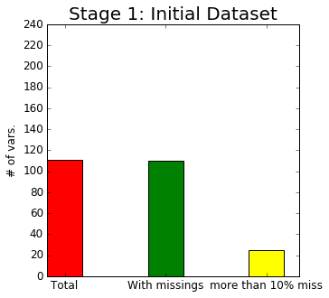

```python
#### Creating Arrays with Values from Each Stage of Cleaning ###
np.asarray(num_var)
np.asarray(c_miss)
np.asarray(c_miss_10)
first_stage = [num_var[0],c_miss[0] , c_miss_10[0]]
second_stage = [num_var[1],c_miss[1] , c_miss_10[1]]
third_stage = [num_var[2],c_miss[2] , c_miss_10[2]]
fourth_stage = [num_var[3],c_miss[3] , c_miss_10[3]]


colors = ['red', 'green', 'yellow']

#charting stage 1 of cleaning#

N = 3
ind = np.arange(N)    # the x locations for the groups
width = 0.35       # the width of the bars: can also be len(x) sequence

plt.subplots(figsize = (5,5))

p1 = plt.bar(ind, first_stage, width, color= colors)

plt.rcParams['font.size']=12.0
plt.ylabel('# of vars.')
plt.title('Stage 1: Initial Dataset' , fontsize = 20)
plt.xticks(ind + width/2., ('Total', 'With missings', 'more than 10% miss'))
plt.yticks(np.arange(0,  250, 20))

plt.savefig('/Users/Dwijo/Google Drive/CS 109/Homework/Final Project/Final Graphs/cleaning_1.png');
```

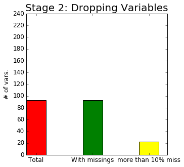

```python
#### Chart 2 ###

plt.subplots(figsize = (5,5))

p1 = plt.bar(ind, second_stage, width, color=colors)

plt.ylabel('# of vars.')
plt.title('Stage 2: Dropping Variables', fontsize = 20)
plt.rcParams['font.size']=12.0
plt.xticks(ind + width/2., ('Total', 'With missings', 'more than 10% miss'))
plt.yticks(np.arange(0,  250, 20))

plt.savefig('/Users/Dwijo/Google Drive/CS 109/Homework/Final Project/Final Graphs/cleaning_2.png');
```

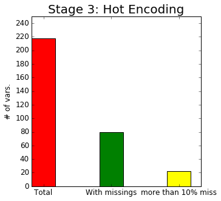

```python
#### Chart 3 ####

plt.subplots(figsize = (5,5))

p1 = plt.bar(ind, third_stage, width, color= colors)

plt.ylabel('# of vars.')
plt.title('Stage 3: Hot Encoding', fontsize = 20)
plt.xticks(ind + width/2., ('Total', 'With missings', 'more than 10% miss'))
plt.yticks(np.arange(0,  250, 20))

plt.savefig('/Users/Dwijo/Google Drive/CS 109/Homework/Final Project/Final Graphs/cleaning_3.png');
```

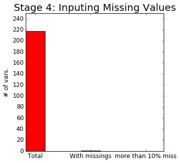

```python
###  Chart 4 ###

plt.subplots(figsize = (5,5))

p1 = plt.bar(ind, fourth_stage, width, color= colors)

plt.ylabel('# of vars.')
plt.title('Stage 4: Inputing Missing Values', fontsize = 20)
plt.xticks(ind + width/2., ('Total', 'With missings', 'more than 10% miss'))
plt.yticks(np.arange(0,  250, 20))

plt.savefig('/Users/Dwijo/Google Drive/CS 109/Homework/Final Project/Final Graphs/cleaning_4.png');
```

### Creating Response Variable

#### Final Step of Cleaning Process

```python
### Now make response variable loan_status binary

#getting rid of null values in loan status
data = data[data['loan_status'].notnull()]

# 1 is default risk
# 0 is no default risk

loan_status = data['loan_status']
loan_status.head(n=2)

loan_status = loan_status.replace(to_replace = ["Fully Paid",
                                      "Charged Off",
                                      "Default",
                                      "Late (31-120 days)",
                                      "Current",
                                      "In Grace Period",
                                      "Late (16-30 days)",
                                      "Does not meet the credit policy. Status:Fully Paid",
                                      "Does not meet the credit policy. Status:Charged Off"],
                                      value = [0.0,
                                               1.0,
                                               1.0,
                                               1.0,
                                               0.0,
                                               0.0,
                                               1.0,
                                               0.0,
                                               1.0])

loan_status = loan_status.apply(lambda x : float(x))

data['loan_status'] = loan_status

loan_status.head(n=2)
```

```
0     Fully Paid
1    Charged Off
Name: loan_status, dtype: object
```

```
0    0.0
1    1.0
Name: loan_status, dtype: float64
```

# Section II: Initial Analysis and Visualization

The three main visualizations in this sections help us understand:

1. Class Balance
2. Graphing Loan Grades vs Riskiness and Interest Rates
3. Tracking Loan Riskiness Over Time

```python
##generating frequency table of loan status
counts_status = data['loan_status'].value_counts()

total_status = counts_status[0] + counts_status[1]

print counts_status[0]
print counts_status[1]

##creating percentage distribution based on loan status frequency
nonrisky_percent = (float(counts_status[0])/total_status)*100
risky_percent = (float(counts_status[1])/total_status)*100
```

```
1013227
105954
```

### Class Balance

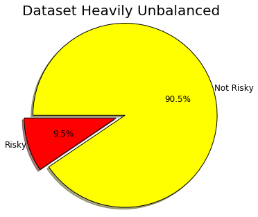

```python
##creating pie chart for loan status

fig, ax = plt.subplots(1, 1, figsize=(5, 5))

labels = ['Risky', 'Not Risky']
sizes = [risky_percent, nonrisky_percent]
colors = ['red', 'yellow']
explode = (0.1, 0)

ax.pie(sizes, explode = explode, labels=labels, colors=colors,
         autopct='%1.1f%%', shadow=True, startangle=180, labeldistance=1.01)

ax.set_title("Dataset Heavily Unbalanced", fontsize = 20)
ax.axis('equal')
plt.rcParams['font.size'] = 12.0

plt.savefig('/Users/Dwijo/Google Drive/CS 109/Homework/Final Project/Final Graphs/Imbalance.png');
```

### Loan Grades vs Risk/Interest Rate

```python
#creating subset of dataframe with loan status, interest rate and loan grade

data_viz = data[['loan_status','int_rate','A', 'B', 'C', 'D', 'E', 'F', 'G']]

#creating list of loan grades
grade_list = ['A', 'B', 'C', 'D', 'E', 'F', 'G']

#creating a column for loan grade
data_viz['grade'] = 0

#running a loop to convert all categorical variables into one column with loan grade
for g in grade_list:
    data_viz.grade[data_viz.loc[:, g]==1.0] = g
    data_viz.drop(g, axis=1, inplace=True)
```

```python
#creating list of loan status
cat_names = {0:'Not Risky', 1:'Risky'}

#creating
for elem in data_viz['loan_status'].unique():
    data_viz[cat_names[elem]] = data_viz['loan_status'] == elem

##creating array with interest rates for each grade
data_viz['int_rate'] = data_viz['int_rate'].replace('%','',regex=True).astype('float')

grade_rate = data_viz.groupby(['grade'], as_index=False)['int_rate'].mean()

##creating array with default rates for each grade
grade_default = data_viz.groupby(['grade'], as_index=False)['loan_status'].mean()

##converting to readable percentage terms
grade_default = grade_default['loan_status']*100

grade_counts = data_viz['grade'].value_counts()
```

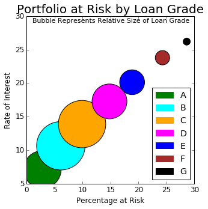

```python
# preparing data for graph
default = [grade_default[0], grade_default[1], grade_default[2],
     grade_default[3], grade_default[4], grade_default[5], grade_default[6]]
rate = [grade_rate.iloc[0, 1], grade_rate.iloc[1, 1], grade_rate.iloc[2, 1],
     grade_rate.iloc[3, 1], grade_rate.iloc[4, 1], grade_rate.iloc[5, 1], grade_rate.iloc[6, 1]]
areas = [grade_counts[2]/50,
         grade_counts[0]/50,
         grade_counts[1]/50,
         grade_counts[3]/50,
         grade_counts[4]/50,
         grade_counts[5]/50,
         grade_counts[6]/50]
labels = ['A', 'B', 'C', 'D', 'E', 'F', 'G']
colors = ['green', 'cyan', 'orange', 'magenta', 'blue', 'brown', 'black']

a = mpatches.Patch(color='green', label='A')
b = mpatches.Patch(color='cyan', label='B')
c = mpatches.Patch(color='orange', label='C')
d = mpatches.Patch(color='magenta', label='D')
e = mpatches.Patch(color='blue', label='E')
f = mpatches.Patch(color='brown', label='F')
g = mpatches.Patch(color='black', label='G')

fig, ax = plt.subplots(1, 1, figsize=(5, 5))

ax.scatter(default, rate, c=colors, s=areas)
ax.legend(loc='best')
ax.set_xlabel('Percentage at Risk', fontsize = 12)
ax.set_ylabel('Rate of Interest', fontsize = 12)
ax.set_title('Portfolio at Risk by Loan Grade', fontsize = 20)
ax.annotate('Bubble' + \
            ' Represents Relative Size of Loan Grade',
            xy = (1, 29), fontsize = 11)

plt.legend(handles=[a, b, c, d, e, f, g], loc='lower right')

plt.savefig('/Users/Dwijo/Google Drive/CS 109/Homework/Final Project/Final Graphs/Risk.png');
```

### Tracking Loan Riskiness Over Time

```python
#Graph loans currently in delinquency or default by year

#create a list of unique dates (month each loan was issued)
date_list = data['issue_d'].unique()
date_list

#generate proportion of loans at risk for a given date
for date in date_list:
    data.loc[(data['issue_d'] == date), 'mean_risk'] = np.mean(data.ix[(data['issue_d'] == date), 'loan_status'])

#generate a mean risk list corresponding to the list of dates for graphing
risk_list = data['mean_risk'].unique()

risk_list

#drop this to ensure models work
data = data.drop('mean_risk', axis = 1)
```

```
array([734472, 734442, 734411, 734381, 734350, 734319, 734289, 734258,
       734228, 734197, 734169, 734138, 734107, 734077, 734046, 734016,
       733985, 733954, 733924, 733893, 733863, 733832, 733804, 733773,
       733742, 733712, 733681, 733651, 733620, 733589, 733559, 733528,
       733498, 733467, 733439, 733408, 733377, 733347, 733316, 733286,
       733255, 733224, 733194, 733163, 733133, 733102, 733073, 733042,
       733011, 732981, 732950, 732920, 732889, 732858, 732828, 735203,
       735173, 735142, 735112, 735081, 735050, 735020, 734989, 734959,
       734928, 734900, 734869, 734838, 734808, 734777, 734747, 734716,
       734685, 734655, 734624, 734594, 734563, 734534, 734503, 735568,
       735538, 735507, 735477, 735446, 735415, 735385, 735354, 735324,
       735293, 735265, 735234, 735933, 735903, 735872, 735842, 735811,
       735780, 735750, 735719, 735689, 735658, 735630, 735599, 736024,
       735995, 735964, 736116, 736085, 736055])
```

```
array([ 0.18879577,  0.15367384,  0.14825307,  0.14997581,  0.1401241 ,
        0.15093333,  0.14822888,  0.17018779,  0.14203455,  0.14502762,
        0.13020031,  0.13478261,  0.12059925,  0.14297386,  0.15340909,
        0.17325484,  0.14638298,  0.1320598 ,  0.17737557,  0.14560162,
        0.11074561,  0.10507246,  0.10997067,  0.13897281,  0.10790274,
        0.14652568,  0.16556291,  0.13017751,  0.11210762,  0.14111922,
        0.14285714,  0.14206128,  0.14714715,  0.12654321,  0.13576159,
        0.15241636,  0.15810277,  0.18660287,  0.17213115,  0.1754386 ,
        0.12      ,  0.21276596,  0.17741935,  0.2173913 ,  0.24324324,
        0.22139303,  0.19934641,  0.27540984,  0.27325581,  0.30357143,
        0.32380952,  0.24528302,  0.27027027,  0.11111111,  0.125     ,
        0.13648469,  0.14055707,  0.14211905,  0.14368214,  0.14328547,
        0.1465995 ,  0.15313331,  0.15642512,  0.15182079,  0.13973166,
        0.14826081,  0.14901048,  0.14457633,  0.1582576 ,  0.1516845 ,
        0.15360605,  0.16239159,  0.17592392,  0.18574797,  0.16647059,
        0.15263158,  0.15305422,  0.1640625 ,  0.16910069,  0.10390996,
        0.11678774,  0.12938659,  0.12917217,  0.13479324,  0.13580837,
        0.13970545,  0.13995497,  0.14120917,  0.14079816,  0.14165957,
        0.14013309,  0.05033489,  0.05363709,  0.05642491,  0.06937607,
        0.071755  ,  0.08002263,  0.09050377,  0.09601103,  0.09856889,
        0.10515748,  0.10437526,  0.1142792 ,  0.03021358,  0.03556882,
        0.04081443,  0.01353766,  0.02045559,  0.02492314])
```

```python
#Create a dataframe to hold chart data

date_frame = pd.DataFrame(date_list, columns = ['Dates'])
risk_frame = pd.DataFrame(risk_list, columns = ['Loans at risk'])

risk_frame = pd.concat((date_frame, risk_frame), axis = 1)

risk_frame.sort(columns = ['Dates'], inplace = True)

risk_frame.head(n=5)
np.shape(risk_frame)
```

|  | Dates | Loans at risk |
| --- | --- | --- |
| 54 | 732828 | 0.125000 |
| 53 | 732858 | 0.111111 |
| 52 | 732889 | 0.270270 |
| 51 | 732920 | 0.245283 |
| 50 | 732950 | 0.323810 |

```
(109, 2)
```

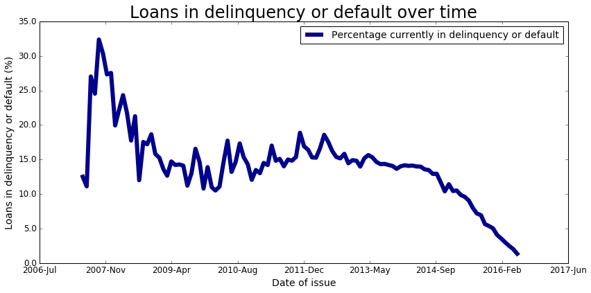

```python
#Use a line graph to chart defaults and delinquencies by month

fig, ax = plt.subplots(figsize = (12,6))

ax.plot(risk_frame['Dates'], risk_frame['Loans at risk'], lw = 6,
        color = 'darkblue', label = 'Percentage currently in delinquency or default')
ax.set_title('Loans in delinquency or default over time', fontsize = 20)
ax.set_xlabel('Date of issue', fontsize = 12)
ax.set_ylabel('Loans in delinquency or default (%)', fontsize = 12)

xticklabels = ax.get_xticks().tolist()
yticklabels = ax.get_yticks().tolist()

for index, label in enumerate(xticklabels):
    xticklabels[index] = dt.date.fromordinal(int(label)).strftime('%Y-%b')

for index, label in enumerate(yticklabels):
    yticklabels[index] = label*100

ax.set_xticklabels(xticklabels)
ax.set_yticklabels(yticklabels)
ax.legend(fontsize = 12)

plt.tight_layout()
plt.savefig('/Users/Dwijo/Google Drive/CS 109/Homework/Final Project/Final Graphs/Loans-delinquency-line.png');
```

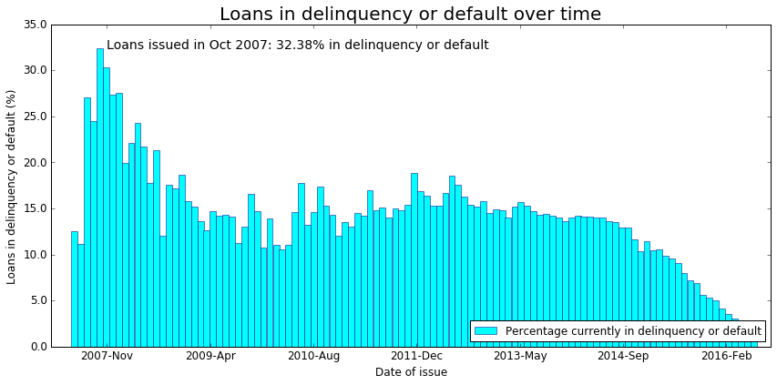

```python
#Use a bar graph to chart defaults and delinquencies by month

fig, ax = plt.subplots(figsize = (12,6))

ax.bar(risk_frame['Dates'], risk_frame['Loans at risk'], linewidth = 0.5, width = 30, align = 'edge',
        facecolor = 'cyan', edgecolor = 'darkblue', label = 'Percentage currently in delinquency or default')
ax.set_title('Loans in delinquency or default over time', fontsize = 20)
ax.set_xlabel('Date of issue', fontsize = 12)
ax.set_ylabel('Loans in delinquency or default (%)', fontsize = 12)

xticklabels = ax.get_xticks().tolist()
yticklabels = ax.get_yticks().tolist()

for index, label in enumerate(xticklabels):
    xticklabels[index] = dt.date.fromordinal(int(label)).strftime('%Y-%b')

for index, label in enumerate(yticklabels):
    yticklabels[index] = label*100

ax.set_xticklabels(xticklabels)
ax.set_yticklabels(yticklabels)
ax.set_xlim(np.amin(risk_frame['Dates'])-100, np.amax(risk_frame['Dates'])+100)
ax.legend(loc = 'lower right', fontsize = 12)
ax.annotate('Loans issued in ' + \
            str(dt.date.fromordinal(int(risk_frame['Dates'][np.argmax(risk_frame['Loans at risk'])])).strftime('%b %Y')) + \
            ': ' + str(np.around(np.amax(risk_frame['Loans at risk'])*100, decimals = 2)) + '% in delinquency or default',
            xy = (risk_frame['Dates'][np.argmax(risk_frame['Loans at risk'])], np.amax(risk_frame['Loans at risk'])),
            xytext = (risk_frame['Dates'][np.argmax(risk_frame['Loans at risk'])] + 50, np.amax(risk_frame['Loans at risk'])),
           fontsize = 12)

plt.tight_layout()
plt.savefig('/Users/Dwijo/Google Drive/CS 109/Homework/Final Project/Final Graphs/Loans-delinquency-bar.png');
```

## Dropping 2016 Data

As we can see in the above graph, loans originating in 2016 have not had enough time to mature and display their true 'riskiness'. In order to make sure our data is representative of the actual riskiness of a loan, we are removing the 2016 data from our model analysis.

```python
#Drop loans issued after January 1, 2016
max_date = dt.datetime(2016, 1, 1)
max_date = dt.datetime.toordinal(max_date)

data = data.ix[data['issue_d'] < max_date,:]
np.shape(data)
```

```
(887440, 218)
```

# Section III: Modelling

General Approach to Modelling:

1) Optimize Parameters on a small subsample of 1% of the data

2) Graph results from all tested parameters to visually compare performance

3) Fit final model with selected optimized paramaters

### Preparing Data for Modelling

```python
# Splitting predictors and y results
y = data.iloc[:, -1]
x = data.iloc[:, :-1].as_matrix()

# # dictionary vectorizing x in order to use strings
# vec = DictVectorizer()
# X = vec.fit_transform([item[0] for item in x]).as_matrix(columns=None)

print 'predictors shape:', x.shape
print 'outcome shape:', y.shape
np.mean(y)
data.head(n=5)
```

```
predictors shape: (887440, 217)
outcome shape: (887440,)
```

```
0.11202785540430903
```

|  | issue_d | loan_amnt | funded_amnt | funded_amnt_inv | term | int_rate | installment | annual_inc | dti | delinq_2yrs | earliest_cr_line | inq_last_6mths | mths_since_last_delinq | mths_since_last_record | open_acc | pub_rec | revol_bal | revol_util | total_acc | recoveries | collection_recovery_fee | last_credit_pull_d | collections_12_mths_ex_med | mths_since_last_major_derog | policy_code | annual_inc_joint | dti_joint | acc_now_delinq | tot_coll_amt | … |
| --- | --- | --- | --- | --- | --- | --- | --- | --- | --- | --- | --- | --- | --- | --- | --- | --- | --- | --- | --- | --- | --- | --- | --- | --- | --- | --- | --- | --- | --- | --- |
| 0 | 734472 | 5000.0 | 5000.0 | 4975.0 | 36.0 | 10.65 | 162.87 | 24000.0 | 27.65 | 0.0 | 724642 | 1.0 | 33.983685 | 69.247045 | 3.0 | 0.0 | 13648.0 | 83.700000 | 9.0 | 0.00 | 0.00 | 736208 | 0.0 | 44.336923 | 1.0 | 108683.595881 | 18.497685 | 0.0 | 233.945249 | … |
| 1 | 734472 | 2500.0 | 2500.0 | 2500.0 | 60.0 | 15.27 | 59.83 | 30000.0 | 1.00 | 0.0 | 729845 | 5.0 | 33.983685 | 69.247045 | 3.0 | 0.0 | 1687.0 | 56.089109 | 4.0 | 117.08 | 1.11 | 736208 | 0.0 | 44.336923 | 1.0 | 108683.595881 | 18.497685 | 0.0 | 233.945249 | … |
| 2 | 734472 | 2400.0 | 2400.0 | 2400.0 | 36.0 | 15.96 | 84.33 | 12252.0 | 8.72 | 0.0 | 730790 | 2.0 | 33.983685 | 69.247045 | 2.0 | 0.0 | 2956.0 | 98.500000 | 10.0 | 0.00 | 0.00 | 736208 | 0.0 | 44.336923 | 1.0 | 108683.595881 | 18.497685 | 0.0 | 233.945249 | … |
| 3 | 734472 | 10000.0 | 10000.0 | 10000.0 | 36.0 | 13.49 | 339.31 | 49200.0 | 20.00 | 0.0 | 728690 | 1.0 | 35.000000 | 69.247045 | 10.0 | 0.0 | 5598.0 | 21.000000 | 37.0 | 0.00 | 0.00 | 736055 | 0.0 | 44.336923 | 1.0 | 108683.595881 | 18.497685 | 0.0 | 233.945249 | … |
| 4 | 734472 | 3000.0 | 3000.0 | 3000.0 | 60.0 | 12.69 | 67.79 | 80000.0 | 17.94 | 0.0 | 728659 | 0.0 | 38.000000 | 69.247045 | 15.0 | 0.0 | 27783.0 | 53.900000 | 38.0 | 0.00 | 0.00 | 736208 | 0.0 | 44.336923 | 1.0 | 108683.595881 | 18.497685 | 0.0 | 233.945249 | … |

5 rows × 218 columns

```python
#Creating Large training and test sample size

#train with 1/3 test with 2/3

x_train, x_test, y_train, y_test = train_test_split(x, y, test_size = .6)
```

```python
#Creating smaller training and test set for optimization

#Take 1% of the data set to tune
data_eval = data.sample(frac = 0.01)

#reindex
data_eval = data_eval.set_index([np.arange(len(data_eval))])

x_sub = data_eval.iloc[:,:-1]

y_sub = data_eval.iloc[:,-1]

#creating training and test set from subsample
x_sub_train, x_sub_test, y_sub_train, y_sub_test = train_test_split(x_sub, y_sub, test_size = .6)
```

Creating a function for choosing sample size for our models. We use a small sample for tuning the parameters, and then fit the optimized model on the larger sample sizes.

```python
def samplesize(tuning):
    if tuning == "Small":
        x_s = x_sub
        y_s = y_sub
        x_tr = x_sub_train
        y_tr = y_sub_train
        x_te = x_sub_test
        y_te = y_sub_test
    elif tuning == "Big":
        x_s = x
        y_s = y
        x_tr = x_train
        y_tr = y_train
        x_te = x_test
        y_te = y_test
    return x_s, y_s, x_tr, y_tr, x_te, y_te
```

```python
##sanity check
x.shape
x_sub.shape
x_sub_train.shape
np.mean(y_sub)
```

```
(887440, 217)
```

```
(8874, 217)
```

```
(3549, 217)
```

```
0.11088573360378634
```

## Random Forests

### Tuning Parameters

```python
# Using a small sample size for optimizing the model
tuning = "Small"

x_s, y_s, x_tr, y_tr, x_te, y_te = samplesize(tuning)

#creating range of trees and depth to test
n_trees = np.arange(10, 60, 10)
depths = np.arange(2, 7)

# To keep track of the best model
best_score = 0

class_error = []
x_axis = []

tree_scores=[]

# Run grid search for model with 5-fold cross validation
print '3-fold cross validation:'

k_folds = KFold(x_s.shape[0], n_folds=3, shuffle=True)
for trees in n_trees:

    depth_scores = []

    for depth in depths:

        # Cross validation for every experiment
        scores = []

        for train_index, test_index in k_folds:
            # Generate training data
            x_train_cv = x_s.ix[train_index,:].values
            y_train_cv = y_s[train_index].values.astype('int')
            # Generate validation data
            x_validate = x_s.ix[test_index,:].values
            y_validate = y_s[test_index].values.astype('int')

            # Fit random forest on training data
            model = ensemble.RandomForestClassifier(n_estimators=trees, max_depth=depth, class_weight = 'balanced')
            model.fit(x_train_cv, y_train_cv)
            # Score on validation data
            scores.append(model.score(x_validate, y_validate))


        # Record and report accuracy
        average_score = np.mean(scores)

        depth_scores.append(average_score)

        print "Trees:", trees, "Depth:", depth, "Score:", average_score

        # Update our record of the best parameters see so far
        if average_score > best_score:
            best_score = average_score
            best_trees = trees
            best_depth = depth

    tree_scores.append(depth_scores);
```

```
3-fold cross validation:
```

[output not shown]

[output not shown]

[output not shown]

```
Trees: 10 Depth: 2 Score: 0.749943655623
```

[output not shown]

[output not shown]

[output not shown]

```
Trees: 10 Depth: 3 Score: 0.908158665765
```

[output not shown]

[output not shown]

[output not shown]

```
Trees: 10 Depth: 4 Score: 0.890917286455
```

[output not shown]

[output not shown]

[output not shown]

```
Trees: 10 Depth: 5 Score: 0.888212756367
```

[output not shown]

[output not shown]

[output not shown]

```
Trees: 10 Depth: 6 Score: 0.892156862745
```

[output not shown]

[output not shown]

[output not shown]

```
Trees: 20 Depth: 2 Score: 0.836150552175
```

[output not shown]

[output not shown]

[output not shown]

```
Trees: 20 Depth: 3 Score: 0.86646382691
```

[output not shown]

```
RandomForestClassifier(bootstrap=True, class_weight='balanced',
            criterion='gini', max_depth=4, max_features='auto',
            max_leaf_nodes=None, min_samples_leaf=1, min_samples_split=2,
            min_weight_fraction_leaf=0.0, n_estimators=20, n_jobs=1,
            oob_score=False, random_state=None, verbose=0,
            warm_start=False)
```

```
RandomForestClassifier(bootstrap=True, class_weight='balanced',
            criterion='gini', max_depth=4, max_features='auto',
            max_leaf_nodes=None, min_samples_leaf=1, min_samples_split=2,
            min_weight_fraction_leaf=0.0, n_estimators=20, n_jobs=1,
            oob_score=False, random_state=None, verbose=0,
            warm_start=False)
```

```
Trees: 20 Depth: 4 Score: 0.881676808654
```

```
RandomForestClassifier(bootstrap=True, class_weight='balanced',
            criterion='gini', max_depth=5, max_features='auto',
            max_leaf_nodes=None, min_samples_leaf=1, min_samples_split=2,
            min_weight_fraction_leaf=0.0, n_estimators=20, n_jobs=1,
            oob_score=False, random_state=None, verbose=0,
            warm_start=False)
```

```
RandomForestClassifier(bootstrap=True, class_weight='balanced',
            criterion='gini', max_depth=5, max_features='auto',
            max_leaf_nodes=None, min_samples_leaf=1, min_samples_split=2,
            min_weight_fraction_leaf=0.0, n_estimators=20, n_jobs=1,
            oob_score=False, random_state=None, verbose=0,
            warm_start=False)
```

```
RandomForestClassifier(bootstrap=True, class_weight='balanced',
            criterion='gini', max_depth=5, max_features='auto',
            max_leaf_nodes=None, min_samples_leaf=1, min_samples_split=2,
            min_weight_fraction_leaf=0.0, n_estimators=20, n_jobs=1,
            oob_score=False, random_state=None, verbose=0,
            warm_start=False)
```

```
Trees: 20 Depth: 5 Score: 0.912778904665
```

```
RandomForestClassifier(bootstrap=True, class_weight='balanced',
            criterion='gini', max_depth=6, max_features='auto',
            max_leaf_nodes=None, min_samples_leaf=1, min_samples_split=2,
            min_weight_fraction_leaf=0.0, n_estimators=20, n_jobs=1,
            oob_score=False, random_state=None, verbose=0,
            warm_start=False)
```

```
RandomForestClassifier(bootstrap=True, class_weight='balanced',
            criterion='gini', max_depth=6, max_features='auto',
            max_leaf_nodes=None, min_samples_leaf=1, min_samples_split=2,
            min_weight_fraction_leaf=0.0, n_estimators=20, n_jobs=1,
            oob_score=False, random_state=None, verbose=0,
            warm_start=False)
```

```
RandomForestClassifier(bootstrap=True, class_weight='balanced',
            criterion='gini', max_depth=6, max_features='auto',
            max_leaf_nodes=None, min_samples_leaf=1, min_samples_split=2,
            min_weight_fraction_leaf=0.0, n_estimators=20, n_jobs=1,
            oob_score=False, random_state=None, verbose=0,
            warm_start=False)
```

```
Trees: 20 Depth: 6 Score: 0.912666215912
```

```
RandomForestClassifier(bootstrap=True, class_weight='balanced',
            criterion='gini', max_depth=2, max_features='auto',
            max_leaf_nodes=None, min_samples_leaf=1, min_samples_split=2,
            min_weight_fraction_leaf=0.0, n_estimators=30, n_jobs=1,
            oob_score=False, random_state=None, verbose=0,
            warm_start=False)
```

```
RandomForestClassifier(bootstrap=True, class_weight='balanced',
            criterion='gini', max_depth=2, max_features='auto',
            max_leaf_nodes=None, min_samples_leaf=1, min_samples_split=2,
            min_weight_fraction_leaf=0.0, n_estimators=30, n_jobs=1,
            oob_score=False, random_state=None, verbose=0,
            warm_start=False)
```

```
RandomForestClassifier(bootstrap=True, class_weight='balanced',
            criterion='gini', max_depth=2, max_features='auto',
            max_leaf_nodes=None, min_samples_leaf=1, min_samples_split=2,
            min_weight_fraction_leaf=0.0, n_estimators=30, n_jobs=1,
            oob_score=False, random_state=None, verbose=0,
            warm_start=False)
```

```
Trees: 30 Depth: 2 Score: 0.835474419653
```

```
RandomForestClassifier(bootstrap=True, class_weight='balanced',
            criterion='gini', max_depth=3, max_features='auto',
            max_leaf_nodes=None, min_samples_leaf=1, min_samples_split=2,
            min_weight_fraction_leaf=0.0, n_estimators=30, n_jobs=1,
            oob_score=False, random_state=None, verbose=0,
            warm_start=False)
```

```
RandomForestClassifier(bootstrap=True, class_weight='balanced',
            criterion='gini', max_depth=3, max_features='auto',
            max_leaf_nodes=None, min_samples_leaf=1, min_samples_split=2,
            min_weight_fraction_leaf=0.0, n_estimators=30, n_jobs=1,
            oob_score=False, random_state=None, verbose=0,
            warm_start=False)
```

```
RandomForestClassifier(bootstrap=True, class_weight='balanced',
            criterion='gini', max_depth=3, max_features='auto',
            max_leaf_nodes=None, min_samples_leaf=1, min_samples_split=2,
            min_weight_fraction_leaf=0.0, n_estimators=30, n_jobs=1,
            oob_score=False, random_state=None, verbose=0,
            warm_start=False)
```

```
Trees: 30 Depth: 3 Score: 0.869731800766
```

```
RandomForestClassifier(bootstrap=True, class_weight='balanced',
            criterion='gini', max_depth=4, max_features='auto',
            max_leaf_nodes=None, min_samples_leaf=1, min_samples_split=2,
            min_weight_fraction_leaf=0.0, n_estimators=30, n_jobs=1,
            oob_score=False, random_state=None, verbose=0,
            warm_start=False)
```

```
RandomForestClassifier(bootstrap=True, class_weight='balanced',
            criterion='gini', max_depth=4, max_features='auto',
            max_leaf_nodes=None, min_samples_leaf=1, min_samples_split=2,
            min_weight_fraction_leaf=0.0, n_estimators=30, n_jobs=1,
            oob_score=False, random_state=None, verbose=0,
            warm_start=False)
```

```
RandomForestClassifier(bootstrap=True, class_weight='balanced',
            criterion='gini', max_depth=4, max_features='auto',
            max_leaf_nodes=None, min_samples_leaf=1, min_samples_split=2,
            min_weight_fraction_leaf=0.0, n_estimators=30, n_jobs=1,
            oob_score=False, random_state=None, verbose=0,
            warm_start=False)
```

```
Trees: 30 Depth: 4 Score: 0.890917286455
```

```
RandomForestClassifier(bootstrap=True, class_weight='balanced',
            criterion='gini', max_depth=5, max_features='auto',
            max_leaf_nodes=None, min_samples_leaf=1, min_samples_split=2,
            min_weight_fraction_leaf=0.0, n_estimators=30, n_jobs=1,
            oob_score=False, random_state=None, verbose=0,
            warm_start=False)
```

```
RandomForestClassifier(bootstrap=True, class_weight='balanced',
            criterion='gini', max_depth=5, max_features='auto',
            max_leaf_nodes=None, min_samples_leaf=1, min_samples_split=2,
            min_weight_fraction_leaf=0.0, n_estimators=30, n_jobs=1,
            oob_score=False, random_state=None, verbose=0,
            warm_start=False)
```

```
RandomForestClassifier(bootstrap=True, class_weight='balanced',
            criterion='gini', max_depth=5, max_features='auto',
            max_leaf_nodes=None, min_samples_leaf=1, min_samples_split=2,
            min_weight_fraction_leaf=0.0, n_estimators=30, n_jobs=1,
            oob_score=False, random_state=None, verbose=0,
            warm_start=False)
```

```
Trees: 30 Depth: 5 Score: 0.904327248141
```

```
RandomForestClassifier(bootstrap=True, class_weight='balanced',
            criterion='gini', max_depth=6, max_features='auto',
            max_leaf_nodes=None, min_samples_leaf=1, min_samples_split=2,
            min_weight_fraction_leaf=0.0, n_estimators=30, n_jobs=1,
            oob_score=False, random_state=None, verbose=0,
            warm_start=False)
```

```
RandomForestClassifier(bootstrap=True, class_weight='balanced',
            criterion='gini', max_depth=6, max_features='auto',
            max_leaf_nodes=None, min_samples_leaf=1, min_samples_split=2,
            min_weight_fraction_leaf=0.0, n_estimators=30, n_jobs=1,
            oob_score=False, random_state=None, verbose=0,
            warm_start=False)
```

```
RandomForestClassifier(bootstrap=True, class_weight='balanced',
            criterion='gini', max_depth=6, max_features='auto',
            max_leaf_nodes=None, min_samples_leaf=1, min_samples_split=2,
            min_weight_fraction_leaf=0.0, n_estimators=30, n_jobs=1,
            oob_score=False, random_state=None, verbose=0,
            warm_start=False)
```

```
Trees: 30 Depth: 6 Score: 0.89970700924
```

```
RandomForestClassifier(bootstrap=True, class_weight='balanced',
            criterion='gini', max_depth=2, max_features='auto',
            max_leaf_nodes=None, min_samples_leaf=1, min_samples_split=2,
            min_weight_fraction_leaf=0.0, n_estimators=40, n_jobs=1,
            oob_score=False, random_state=None, verbose=0,
            warm_start=False)
```

```
RandomForestClassifier(bootstrap=True, class_weight='balanced',
            criterion='gini', max_depth=2, max_features='auto',
            max_leaf_nodes=None, min_samples_leaf=1, min_samples_split=2,
            min_weight_fraction_leaf=0.0, n_estimators=40, n_jobs=1,
            oob_score=False, random_state=None, verbose=0,
            warm_start=False)
```

```
RandomForestClassifier(bootstrap=True, class_weight='balanced',
            criterion='gini', max_depth=2, max_features='auto',
            max_leaf_nodes=None, min_samples_leaf=1, min_samples_split=2,
            min_weight_fraction_leaf=0.0, n_estimators=40, n_jobs=1,
            oob_score=False, random_state=None, verbose=0,
            warm_start=False)
```

```
Trees: 40 Depth: 2 Score: 0.888100067613
```

```
RandomForestClassifier(bootstrap=True, class_weight='balanced',
            criterion='gini', max_depth=3, max_features='auto',
            max_leaf_nodes=None, min_samples_leaf=1, min_samples_split=2,
            min_weight_fraction_leaf=0.0, n_estimators=40, n_jobs=1,
            oob_score=False, random_state=None, verbose=0,
            warm_start=False)
```

```
RandomForestClassifier(bootstrap=True, class_weight='balanced',
            criterion='gini', max_depth=3, max_features='auto',
            max_leaf_nodes=None, min_samples_leaf=1, min_samples_split=2,
            min_weight_fraction_leaf=0.0, n_estimators=40, n_jobs=1,
            oob_score=False, random_state=None, verbose=0,
            warm_start=False)
```

```
RandomForestClassifier(bootstrap=True, class_weight='balanced',
            criterion='gini', max_depth=3, max_features='auto',
            max_leaf_nodes=None, min_samples_leaf=1, min_samples_split=2,
            min_weight_fraction_leaf=0.0, n_estimators=40, n_jobs=1,
            oob_score=False, random_state=None, verbose=0,
            warm_start=False)
```

```
Trees: 40 Depth: 3 Score: 0.89046653144
```

```
RandomForestClassifier(bootstrap=True, class_weight='balanced',
            criterion='gini', max_depth=4, max_features='auto',
            max_leaf_nodes=None, min_samples_leaf=1, min_samples_split=2,
            min_weight_fraction_leaf=0.0, n_estimators=40, n_jobs=1,
            oob_score=False, random_state=None, verbose=0,
            warm_start=False)
```

```
RandomForestClassifier(bootstrap=True, class_weight='balanced',
            criterion='gini', max_depth=4, max_features='auto',
            max_leaf_nodes=None, min_samples_leaf=1, min_samples_split=2,
            min_weight_fraction_leaf=0.0, n_estimators=40, n_jobs=1,
            oob_score=False, random_state=None, verbose=0,
            warm_start=False)
```

```
RandomForestClassifier(bootstrap=True, class_weight='balanced',
            criterion='gini', max_depth=4, max_features='auto',
            max_leaf_nodes=None, min_samples_leaf=1, min_samples_split=2,
            min_weight_fraction_leaf=0.0, n_estimators=40, n_jobs=1,
            oob_score=False, random_state=None, verbose=0,
            warm_start=False)
```

```
Trees: 40 Depth: 4 Score: 0.886184358801
```

```
RandomForestClassifier(bootstrap=True, class_weight='balanced',
            criterion='gini', max_depth=5, max_features='auto',
            max_leaf_nodes=None, min_samples_leaf=1, min_samples_split=2,
            min_weight_fraction_leaf=0.0, n_estimators=40, n_jobs=1,
            oob_score=False, random_state=None, verbose=0,
            warm_start=False)
```

```
RandomForestClassifier(bootstrap=True, class_weight='balanced',
            criterion='gini', max_depth=5, max_features='auto',
            max_leaf_nodes=None, min_samples_leaf=1, min_samples_split=2,
            min_weight_fraction_leaf=0.0, n_estimators=40, n_jobs=1,
            oob_score=False, random_state=None, verbose=0,
            warm_start=False)
```

```
RandomForestClassifier(bootstrap=True, class_weight='balanced',
            criterion='gini', max_depth=5, max_features='auto',
            max_leaf_nodes=None, min_samples_leaf=1, min_samples_split=2,
            min_weight_fraction_leaf=0.0, n_estimators=40, n_jobs=1,
            oob_score=False, random_state=None, verbose=0,
            warm_start=False)
```

```
Trees: 40 Depth: 5 Score: 0.901735406806
```

```
RandomForestClassifier(bootstrap=True, class_weight='balanced',
            criterion='gini', max_depth=6, max_features='auto',
            max_leaf_nodes=None, min_samples_leaf=1, min_samples_split=2,
            min_weight_fraction_leaf=0.0, n_estimators=40, n_jobs=1,
            oob_score=False, random_state=None, verbose=0,
            warm_start=False)
```

```
RandomForestClassifier(bootstrap=True, class_weight='balanced',
            criterion='gini', max_depth=6, max_features='auto',
            max_leaf_nodes=None, min_samples_leaf=1, min_samples_split=2,
            min_weight_fraction_leaf=0.0, n_estimators=40, n_jobs=1,
            oob_score=False, random_state=None, verbose=0,
            warm_start=False)
```

```
RandomForestClassifier(bootstrap=True, class_weight='balanced',
            criterion='gini', max_depth=6, max_features='auto',
            max_leaf_nodes=None, min_samples_leaf=1, min_samples_split=2,
            min_weight_fraction_leaf=0.0, n_estimators=40, n_jobs=1,
            oob_score=False, random_state=None, verbose=0,
            warm_start=False)
```

```
Trees: 40 Depth: 6 Score: 0.90522875817
```

```
RandomForestClassifier(bootstrap=True, class_weight='balanced',
            criterion='gini', max_depth=2, max_features='auto',
            max_leaf_nodes=None, min_samples_leaf=1, min_samples_split=2,
            min_weight_fraction_leaf=0.0, n_estimators=50, n_jobs=1,
            oob_score=False, random_state=None, verbose=0,
            warm_start=False)
```

```
RandomForestClassifier(bootstrap=True, class_weight='balanced',
            criterion='gini', max_depth=2, max_features='auto',
            max_leaf_nodes=None, min_samples_leaf=1, min_samples_split=2,
            min_weight_fraction_leaf=0.0, n_estimators=50, n_jobs=1,
            oob_score=False, random_state=None, verbose=0,
            warm_start=False)
```

```
RandomForestClassifier(bootstrap=True, class_weight='balanced',
            criterion='gini', max_depth=2, max_features='auto',
            max_leaf_nodes=None, min_samples_leaf=1, min_samples_split=2,
            min_weight_fraction_leaf=0.0, n_estimators=50, n_jobs=1,
            oob_score=False, random_state=None, verbose=0,
            warm_start=False)
```

```
Trees: 50 Depth: 2 Score: 0.905341446924
```

```
RandomForestClassifier(bootstrap=True, class_weight='balanced',
            criterion='gini', max_depth=3, max_features='auto',
            max_leaf_nodes=None, min_samples_leaf=1, min_samples_split=2,
            min_weight_fraction_leaf=0.0, n_estimators=50, n_jobs=1,
            oob_score=False, random_state=None, verbose=0,
            warm_start=False)
```

```
RandomForestClassifier(bootstrap=True, class_weight='balanced',
            criterion='gini', max_depth=3, max_features='auto',
            max_leaf_nodes=None, min_samples_leaf=1, min_samples_split=2,
            min_weight_fraction_leaf=0.0, n_estimators=50, n_jobs=1,
            oob_score=False, random_state=None, verbose=0,
            warm_start=False)
```

```
RandomForestClassifier(bootstrap=True, class_weight='balanced',
            criterion='gini', max_depth=3, max_features='auto',
            max_leaf_nodes=None, min_samples_leaf=1, min_samples_split=2,
            min_weight_fraction_leaf=0.0, n_estimators=50, n_jobs=1,
            oob_score=False, random_state=None, verbose=0,
            warm_start=False)
```

```
Trees: 50 Depth: 3 Score: 0.883592517467
```

```
RandomForestClassifier(bootstrap=True, class_weight='balanced',
            criterion='gini', max_depth=4, max_features='auto',
            max_leaf_nodes=None, min_samples_leaf=1, min_samples_split=2,
            min_weight_fraction_leaf=0.0, n_estimators=50, n_jobs=1,
            oob_score=False, random_state=None, verbose=0,
            warm_start=False)
```

```
RandomForestClassifier(bootstrap=True, class_weight='balanced',
            criterion='gini', max_depth=4, max_features='auto',
            max_leaf_nodes=None, min_samples_leaf=1, min_samples_split=2,
            min_weight_fraction_leaf=0.0, n_estimators=50, n_jobs=1,
            oob_score=False, random_state=None, verbose=0,
            warm_start=False)
```

```
RandomForestClassifier(bootstrap=True, class_weight='balanced',
            criterion='gini', max_depth=4, max_features='auto',
            max_leaf_nodes=None, min_samples_leaf=1, min_samples_split=2,
            min_weight_fraction_leaf=0.0, n_estimators=50, n_jobs=1,
            oob_score=False, random_state=None, verbose=0,
            warm_start=False)
```

```
Trees: 50 Depth: 4 Score: 0.896551724138
```

```
RandomForestClassifier(bootstrap=True, class_weight='balanced',
            criterion='gini', max_depth=5, max_features='auto',
            max_leaf_nodes=None, min_samples_leaf=1, min_samples_split=2,
            min_weight_fraction_leaf=0.0, n_estimators=50, n_jobs=1,
            oob_score=False, random_state=None, verbose=0,
            warm_start=False)
```

```
RandomForestClassifier(bootstrap=True, class_weight='balanced',
            criterion='gini', max_depth=5, max_features='auto',
            max_leaf_nodes=None, min_samples_leaf=1, min_samples_split=2,
            min_weight_fraction_leaf=0.0, n_estimators=50, n_jobs=1,
            oob_score=False, random_state=None, verbose=0,
            warm_start=False)
```

```
RandomForestClassifier(bootstrap=True, class_weight='balanced',
            criterion='gini', max_depth=5, max_features='auto',
            max_leaf_nodes=None, min_samples_leaf=1, min_samples_split=2,
            min_weight_fraction_leaf=0.0, n_estimators=50, n_jobs=1,
            oob_score=False, random_state=None, verbose=0,
            warm_start=False)
```

```
Trees: 50 Depth: 5 Score: 0.915596123507
```

```
RandomForestClassifier(bootstrap=True, class_weight='balanced',
            criterion='gini', max_depth=6, max_features='auto',
            max_leaf_nodes=None, min_samples_leaf=1, min_samples_split=2,
            min_weight_fraction_leaf=0.0, n_estimators=50, n_jobs=1,
            oob_score=False, random_state=None, verbose=0,
            warm_start=False)
```

```
RandomForestClassifier(bootstrap=True, class_weight='balanced',
            criterion='gini', max_depth=6, max_features='auto',
            max_leaf_nodes=None, min_samples_leaf=1, min_samples_split=2,
            min_weight_fraction_leaf=0.0, n_estimators=50, n_jobs=1,
            oob_score=False, random_state=None, verbose=0,
            warm_start=False)
```

```
RandomForestClassifier(bootstrap=True, class_weight='balanced',
            criterion='gini', max_depth=6, max_features='auto',
            max_leaf_nodes=None, min_samples_leaf=1, min_samples_split=2,
            min_weight_fraction_leaf=0.0, n_estimators=50, n_jobs=1,
            oob_score=False, random_state=None, verbose=0,
            warm_start=False)
```

```
Trees: 50 Depth: 6 Score: 0.910975884607
```

### Plotting Random Forest Parameter Optimization

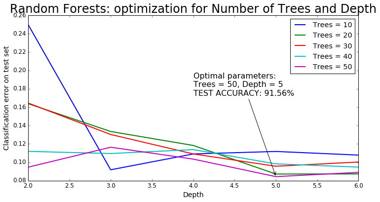

```python
fig, ax = plt.subplots(1, 1, figsize=(12, 6))

for index, score in enumerate(tree_scores):
    label = str(n_trees[index])
    for index, value in enumerate(score):
        score[index] = 1- value
    ax.plot(depths, score, lw = 2, label = ('Trees = ' + label))

ax.set_title('Random Forests: optimization for Number of Trees and Depth', fontsize = 20)
ax.set_xlabel('Depth', fontsize = 12)
ax.set_ylabel('Classification error on test set', fontsize = 12)
ax.annotate('Optimal parameters:\nTrees = ' + str(best_trees) + ", Depth = " + str(best_depth) + \
            '\nTEST ACCURACY: ' + str(np.around(best_score, decimals = 4)*100) + '%',
            xy = (best_depth, (1-best_score)), xytext = (best_depth - 1, (1-best_score) + 0.1),
           arrowprops = dict(arrowstyle="->", connectionstyle="arc3"), fontsize = 14, va='center')
ax.legend(loc = 'best')
plt.savefig('/Users/Dwijo/Google Drive/CS 109/Homework/Final Project/Final Graphs/RF_opt.png');
```

### Fitting Larger Sample with Optimized Random Forest

```python
#Using a large dataset for fitting the model
tuning = "Big"

x_s, y_s, x_tr, y_tr, x_te, y_te = samplesize(tuning)

rf = ensemble.RandomForestClassifier(n_estimators=best_trees, max_depth=best_depth, class_weight = 'balanced')
rf.fit(x_tr, y_tr)

accuracy_rf = rf.score(x_te, y_te)

print "Accuracy of optimized Random Forest is " + str(accuracy_rf*100) + "%."
```

```
RandomForestClassifier(bootstrap=True, class_weight='balanced',
            criterion='gini', max_depth=5, max_features='auto',
            max_leaf_nodes=None, min_samples_leaf=1, min_samples_split=2,
            min_weight_fraction_leaf=0.0, n_estimators=50, n_jobs=1,
            oob_score=False, random_state=None, verbose=0,
            warm_start=False)
```

[output not shown]

## Log Reg

### Optimizing L1 Penalty

```python
# Using a small sample size for optimizing the model
tuning = "Small"

x_s, y_s, x_tr, y_tr, x_te, y_te = samplesize(tuning)

#setting parameters for optimization
C_list = np.logspace(-8, 8)
folds = np.arange(1,4)

#optimizing Log Rev CV with L1 penalty
log_reg_test = LogRegCV(Cs = C_list, solver = 'liblinear', penalty = 'l1', \
                   cv = KFold(np.shape(x)[1], n_folds = folds[-1], shuffle = True),
                      class_weight = 'balanced', \
                   max_iter = len(C_list), \
                   refit = True)

#fit, predict and score
log_reg_test.fit(x_tr, y_tr)
accuracy1 = log_reg_test.score(x_te, y_te)

print "Log Reg chooses a L1 regularization parameter (lambda) of " + str(1/log_reg_test.C_[0]) + "."
print "Log Reg with L1 Penalty " + str(np.count_nonzero(log_reg_test.coef_)) + \
      " non-zero coefficients out of " + str(np.shape(x)[1]) + " total predictors."
print "Accuracy of optimized Log Reg with L1 penalty is " + str(accuracy1*100) + "%."
```

```
LogisticRegressionCV(Cs=array([  1.00000e-08,   2.12095e-08,   4.49843e-08,   9.54095e-08,
         2.02359e-07,   4.29193e-07,   9.10298e-07,   1.93070e-06,
         4.09492e-06,   8.68511e-06,   1.84207e-05,   3.90694e-05,
         8.28643e-05,   1.75751e-04,   3.72759e-04,   7.90604e-04,
         1.67683e-03,   3.556...     2.32995e+06,   4.94171e+06,   1.04811e+07,   2.22300e+07,
         4.71487e+07,   1.00000e+08]),
           class_weight='balanced',
           cv=sklearn.cross_validation.KFold(n=217, n_folds=3, shuffle=True, random_state=None),
           dual=False, fit_intercept=True, intercept_scaling=1.0,
           max_iter=50, multi_class='ovr', n_jobs=1, penalty='l1',
           random_state=None, refit=True, scoring=None, solver='liblinear',
           tol=0.0001, verbose=0)
```

```
Log Reg chooses a L1 regularization parameter (lambda) of 100000000.0.
Log Reg with L1 Penalty 0 non-zero coefficients out of 217 total predictors.
Accuracy of optimized Log Reg with L1 penalty is 88.882629108%.
```